# Assessing Influential Points in Regression

### Show R Demonstration

Below, the `ols_plot_resid_lev(lm_name)` shows the outliers within our data set. From this, we can visibly detect our outlier being point #4.

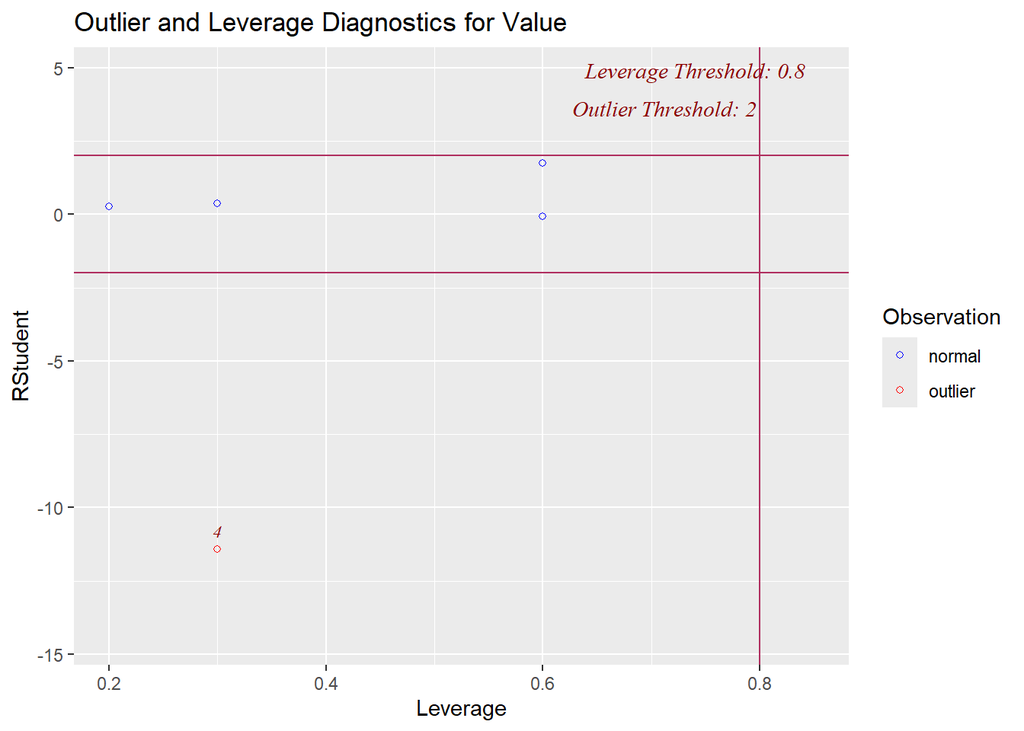

```r
ols_plot_resid_lev(out.lm)
```

Now that we confirmed that our regression does indeed have outliers, we will conduct a **Robust Regression**, but we will do so along side our **Simple Linear Regression** to see just how much our graphics and results are impacted.

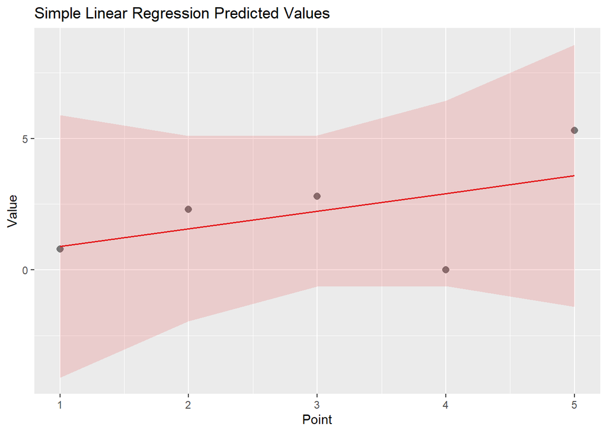

```r
lm.plot <- plot_model(out.lm, type="pred", show.data = T)

lm.plot + ggtitle("Simple Linear Regression Predicted Values")
```

```r
tab_model(out.lm)
```

|  | Value |  |  |
| --- | --- | --- | --- |
| Predictors | Estimates | CI | p |
| (Intercept) | 0.23 | -6.52 – 6.98 | 0.921 |
| Point | 0.67 | -1.37 – 2.71 | 0.372 |
| Observations | 5 |  |  |
| R<sup>2</sup> / R<sup>2</sup> adjusted | 0.268 / 0.024 |  |  |

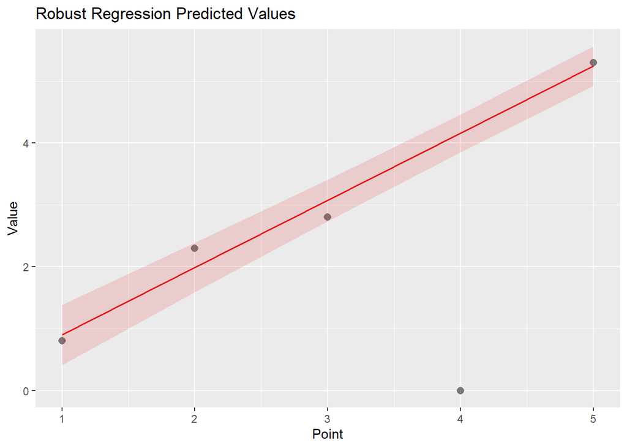

```r
outie.rm <- lmrob(Value ~ Point, data=outie)

rm.plot <- plot_model(outie.rm, type="pred", show.data = T)

rm.plot + ggtitle("Robust Regression Predicted Values")
```

```r
tab_model(outie.rm)
```

|  | Value |  |  |
| --- | --- | --- | --- |
| Predictors | Estimates | CI | p |
| (Intercept) | -0.19 | -0.77 – 0.39 | 0.380 |
| Point | 1.09 | 0.97 – 1.21 | **<0.001** |
| Observations | 5 |  |  |
| R<sup>2</sup> / R<sup>2</sup> adjusted | 0.979 / 0.972 |  |  |

The analysis reveals striking differences between Simple Linear and Robust Regression approaches. Robust Regression demonstrates clearer trends with narrower confidence intervals, indicating greater reliability in the results. Its higher R-squared value and statistical significance stand in sharp contrast to the non-significant results from Simple Linear Regression.

These findings underscore a critical point: *failing to properly identify and handle influential points and outliers can not only lead to incorrect conclusions but potentially mask important discoveries*. This emphasizes the importance of careful outlier analysis using appropriate statistical methods.